# Lab Five: Wide and Deep Networks

The goal of this project is to evaluate two different deep learning architectures and tune hyper-parameters for each architecture using the [Automobile Loan Default](https://www.kaggle.com/datasets/saurabhbagchi/dish-network-hackathon) dataset.

## Preparation

```python
import pandas as pd
import numpy as np
from sklearn.preprocessing import LabelEncoder
from sklearn.model_selection import train_test_split
```

```python
data = pd.read_csv('dataset_5.csv')
```

### Remove variables that are not needed/useful for the analysis:

```python
drop_cols = ["ID", "Accompany_Client", "Client_Gender", "Client_Housing_Type", "Registration_Days", "ID_Days",
 "Mobile_Tag", "Homephone_Tag", "Workphone_Working", "Cleint_City_Rating", "Application_Process_Day", "Application_Process_Hour",
 "Client_Permanent_Match_Tag", "Client_Contact_Work_Tag", "Type_Organization", "Social_Circle_Default", "Phone_Change","Credit_Bureau"]

data.drop(drop_cols, axis=1, inplace=True)
```

```python
data
```

|  | Client_Income | Car_Owned | Bike_Owned | Active_Loan | House_Own | Child_Count | Credit_Amount | Loan_Annuity | Client_Income_Type | Client_Education | ... | Population_Region_Relative | Age_Days | Employed_Days | Own_House_Age | Client_Occupation | Client_Family_Members | Score_Source_1 | Score_Source_2 | Score_Source_3 | Default |
| --- | --- | --- | --- | --- | --- | --- | --- | --- | --- | --- | --- | --- | --- | --- | --- | --- | --- | --- | --- | --- | --- |
| 0 | 6750 | 0.0 | 0.0 | 1.0 | 0.0 | 0.0 | 61190.55 | 3416.85 | Commercial | Secondary | ... | 0.028663 | 13957 | 1062 | NaN | Sales | 2.0 | 0.568066 | 0.478787 | NaN | 0 |
| 1 | 20250 | 1.0 | 0.0 | 1.0 | NaN | 0.0 | 15282 | 1826.55 | Service | Graduation | ... | 0.008575 | 14162 | 4129 | 0.0 | NaN | 2.0 | 0.563360 | 0.215068 | NaN | 0 |
| 2 | 18000 | 0.0 | 0.0 | 1.0 | 0.0 | 1.0 | 59527.35 | 2788.2 | Service | Graduation dropout | ... | 0.0228 | 16790 | 5102 | NaN | Realty agents | 2.0 | NaN | 0.552795 | 0.329655 | 0 |
| 3 | 15750 | 0.0 | 0.0 | 1.0 | 1.0 | 0.0 | 53870.4 | 2295.45 | Retired | Secondary | ... | 0.010556 | 23195 | 365243 | NaN | NaN | 2.0 | NaN | 0.135182 | 0.631355 | 0 |
| 4 | 33750 | 1.0 | 0.0 | 1.0 | 0.0 | 2.0 | 133988.4 | 3547.35 | Commercial | Secondary | ... | 0.020713 | 11366 | 2977 | 6.0 | Laborers | 4.0 | 0.508199 | 0.301182 | 0.355639 | 0 |
| ... | ... | ... | ... | ... | ... | ... | ... | ... | ... | ... | ... | ... | ... | ... | ... | ... | ... | ... | ... | ... | ... |
| 121851 | 29250 | 0.0 | 0.0 | NaN | 1.0 | 0.0 | 107820 | 3165.3 | Service | Secondary | ... | 0.031329 | 12889.0 | 2863.0 | NaN | Laborers | 2.0 | NaN | 0.173527 | 0.184116 | 1 |
| 121852 | 15750 | 0.0 | 1.0 | 1.0 | 0.0 | 0.0 | 104256 | 3388.05 | Commercial | Graduation | ... | 0.018209 | 8648.0 | 636.0 | NaN | Sales | 2.0 | NaN | 0.371559 | 0.406617 | 0 |
| 121853 | 8100 | 0.0 | 1.0 | 0.0 | 1.0 | 1.0 | 55107.9 | 2989.35 | Govt Job | Secondary | ... | 0.008068 | 9152.0 | 1623.0 | NaN | High skill tech | 3.0 | 0.169049 | 0.048079 | NaN | 0 |
| 121854 | 38250 | 1.0 | 1.0 | 0.0 | 1.0 | 0.0 | 45000 | 2719.35 | Service | Graduation | ... | 0.028663 | 10290.0 | 847.0 | 4.0 | Sales | 2.0 | 0.182737 | 0.103538 | 0.077499 | 0 |
| 121855 | 9000 | 1.0 | 1.0 | 1.0 | 1.0 | 1.0 | 62428.95 | 4201.65 | Commercial | Secondary | ... | 0.018029 | 14772.0 | 498.0 | 6.0 | Managers | 2.0 | NaN | 0.556414 | 0.298595 | 0 |

121856 rows × 22 columns

### Percentage of Missing Data in new dataset:

The percentage of variables with missing data in the new dataset are shown below. A few of the remaining variables in the new dataset have a good amount of missing data, and removing blank rows will remove a large amount of data from other variables. Therefore, I am going to remove all variables with more than 20% data missing in the new dataset:

- Own_House_Age: 66%
- Client_Occupation: 34%
- Score_Source_1: 56%
- Score_Source_3: 22%

```python
for col in data.columns:
    pct_missing = np.mean(data[col].isnull())
    print('{}: {}%'.format(col, round(pct_missing*100)))
```

```
Client_Income: 3%
Car_Owned: 3%
Bike_Owned: 3%
Active_Loan: 3%
House_Own: 3%
Child_Count: 3%
Credit_Amount: 3%
Loan_Annuity: 4%
Client_Income_Type: 3%
Client_Education: 3%
Client_Marital_Status: 3%
Loan_Contract_Type: 3%
Population_Region_Relative: 4%
Age_Days: 3%
Employed_Days: 3%
Own_House_Age: 66%
Client_Occupation: 34%
Client_Family_Members: 2%
Score_Source_1: 56%
Score_Source_2: 5%
Score_Source_3: 22%
Default: 0%
```

### Drop Variables with more than 20% of data missing:

```python
drop_cols = ["Own_House_Age", "Client_Occupation", "Score_Source_1", "Score_Source_3"]
data.drop(drop_cols, axis=1, inplace=True)
data.dropna(inplace=True)
```

### New Dataset:

```python
data
```

|  | Client_Income | Car_Owned | Bike_Owned | Active_Loan | House_Own | Child_Count | Credit_Amount | Loan_Annuity | Client_Income_Type | Client_Education | Client_Marital_Status | Loan_Contract_Type | Population_Region_Relative | Age_Days | Employed_Days | Client_Family_Members | Score_Source_2 | Default |
| --- | --- | --- | --- | --- | --- | --- | --- | --- | --- | --- | --- | --- | --- | --- | --- | --- | --- | --- |
| 0 | 6750 | 0.0 | 0.0 | 1.0 | 0.0 | 0.0 | 61190.55 | 3416.85 | Commercial | Secondary | M | CL | 0.028663 | 13957 | 1062 | 2.0 | 0.478787 | 0 |
| 2 | 18000 | 0.0 | 0.0 | 1.0 | 0.0 | 1.0 | 59527.35 | 2788.2 | Service | Graduation dropout | W | CL | 0.0228 | 16790 | 5102 | 2.0 | 0.552795 | 0 |
| 3 | 15750 | 0.0 | 0.0 | 1.0 | 1.0 | 0.0 | 53870.4 | 2295.45 | Retired | Secondary | M | CL | 0.010556 | 23195 | 365243 | 2.0 | 0.135182 | 0 |
| 4 | 33750 | 1.0 | 0.0 | 1.0 | 0.0 | 2.0 | 133988.4 | 3547.35 | Commercial | Secondary | M | CL | 0.020713 | 11366 | 2977 | 4.0 | 0.301182 | 0 |
| 5 | 11250 | 0.0 | 1.0 | 1.0 | 1.0 | 1.0 | 13752 | 653.85 | Service | Secondary | W | CL | 0.019101 | 13881 | 1184 | 2.0 | 0.697928 | 0 |
| ... | ... | ... | ... | ... | ... | ... | ... | ... | ... | ... | ... | ... | ... | ... | ... | ... | ... | ... |
| 121850 | 12150 | 0.0 | 0.0 | 1.0 | 0.0 | 0.0 | 78192 | 2383.65 | Retired | Secondary | S | CL | 0.01885 | 23943.0 | 365243.0 | 1.0 | 0.678249 | 0 |
| 121852 | 15750 | 0.0 | 1.0 | 1.0 | 0.0 | 0.0 | 104256 | 3388.05 | Commercial | Graduation | M | CL | 0.018209 | 8648.0 | 636.0 | 2.0 | 0.371559 | 0 |
| 121853 | 8100 | 0.0 | 1.0 | 0.0 | 1.0 | 1.0 | 55107.9 | 2989.35 | Govt Job | Secondary | M | CL | 0.008068 | 9152.0 | 1623.0 | 3.0 | 0.048079 | 0 |
| 121854 | 38250 | 1.0 | 1.0 | 0.0 | 1.0 | 0.0 | 45000 | 2719.35 | Service | Graduation | M | CL | 0.028663 | 10290.0 | 847.0 | 2.0 | 0.103538 | 0 |
| 121855 | 9000 | 1.0 | 1.0 | 1.0 | 1.0 | 1.0 | 62428.95 | 4201.65 | Commercial | Secondary | S | CL | 0.018029 | 14772.0 | 498.0 | 2.0 | 0.556414 | 0 |

70918 rows × 18 columns

### Attributes of the new dataset:

In this new dataset, we have data types of float, integer and string. The new data types are show below. In the next step, I will be removing all variables with non-numerical values.

- Client_Income, represented in dollars, is stored as an integer.
- Car_Owned is a categorical variable indicating whether my client owns another car, with 1 for Yes and 0 for No.
- Similarly, Bike_Owned is a categorical variable denoting if my client owns a bike, using 1 for Yes and 0 for No.
- Active_Loan is a categorical variable indicating if my client currently has another active loan, with 1 for Yes and 0 for No.
- House_Own is a categorical variable representing whether my client owns a house, utilizing 1 for Yes and 0 for No.
- Child_Count is an integer value indicating the number of children my client has.
- Credit_Amount represents the credit amount of the loan in dollars, stored as an integer.
- Loan_Annuity represents the loan annuity in dollars, stored as an integer.
- Client_Income_Type is a categorical variable describing the type of income my client receives.
- Client_Education is a categorical variable indicating the education level of my client.
- Client_Marital_Status is a categorical variable denoting the marital status of my client.
- Loan_Contract_Type is a categorical variable representing the type of loan contract.
- Population_Region_Relative is a float representing the normalized population of the region where my client resides.
- Age_Days represents the age of my client in days, stored as an integer.
- Employed_Days indicates the number of days my client has been employed, stored as an integer.
- Client_Family_Members is an integer indicating the number of family members my client has.
- Score_Source_2 is a float representing the normalized score from an external data source.
- Default is a categorical variable with 1 for Yes if my client defaulted on the loan, and 0 for No otherwise.

### Dropping all rows in the dataset without numerical values:

```python
columns = ["Employed_Days", "Age_Days", "Client_Income", "Credit_Amount", "Loan_Annuity", "Population_Region_Relative"]

print(len(data))
for col in columns:
    data = data[data[col] != 'x']
    data = data[data[col] != '$']
    data = data[data[col] != '@']
    data = data[data[col] != '#']
    data = data[data[col] != '#VALUE!']
print(len(data))

for col in columns:
    data[col] = data[col].astype('float64')
```

```
70918
70882
```

Now, the new dataset only has data of float or int values with 4 objects which will be converted to string values.

```python
data.dtypes
```

```
Client_Income                 float64
Car_Owned                     float64
Bike_Owned                    float64
Active_Loan                   float64
House_Own                     float64
Child_Count                   float64
Credit_Amount                 float64
Loan_Annuity                  float64
Client_Income_Type             object
Client_Education               object
Client_Marital_Status          object
Loan_Contract_Type             object
Population_Region_Relative    float64
Age_Days                      float64
Employed_Days                 float64
Client_Family_Members         float64
Score_Source_2                float64
Default                         int64
dtype: object
```

### Split dataset in categorical and numerical variables:

```python
categorical_headers = ["Client_Income_Type", "Client_Education", "Client_Marital_Status", "Loan_Contract_Type", "Car_Owned", "Bike_Owned", "Active_Loan", "House_Own"]
numerical_headers = ["Client_Income","Child_Count", "Credit_Amount","Loan_Annuity","Population_Region_Relative","Age_Days","Employed_Days","Client_Family_Members", "Score_Source_2"]
```

### Convert all of the categorical variables into string data types:

```python
for col in categorical_headers:
    data[col] = data[col].astype('str')
```

### Final Dataset:

```python
data.dtypes
```

```
Client_Income                 float64
Car_Owned                      object
Bike_Owned                     object
Active_Loan                    object
House_Own                      object
Child_Count                   float64
Credit_Amount                 float64
Loan_Annuity                  float64
Client_Income_Type             object
Client_Education               object
Client_Marital_Status          object
Loan_Contract_Type             object
Population_Region_Relative    float64
Age_Days                      float64
Employed_Days                 float64
Client_Family_Members         float64
Score_Source_2                float64
Default                         int64
dtype: object
```

### Description of new dataset with newly formed variables

Client_Income (float64): The client's income.

Car_Owned (str): Whether the client owns a car.

Bike_Owned (str): Whether the client owns a bike.

Active_Loan (str): Whether the client has an active loan.

House_Own (str): Whether the client owns a house.

Child_Count (float64): The number of children in the client's family.

Credit_Amount (float64): The amount of credit requested or taken by the client.

Loan_Annuity (float64): The annuity of the loan.

Client_Income_Type (str): The type of income the client has.

Client_Education (str): The client's education level.

Client_Marital_Status (str): The client's marital status.

Loan_Contract_Type (str): The type of loan contract.

Population_Region_Relative (float64): A measure of population relative to the region.

Age_Days (float64): The age of the client in days.

Employed_Days (float64): The number of days the client has been employed.

Client_Family_Members (float64): The number of family members in the client's household.

Score_Source_2 (float64): A numerical score source, possibly a credit score.

Default (int64): The target variable indicating whether the client defaulted on an automobile loan (1 for default, 0 for no default).

### Metrics for Algorithm Performance Evaluation

To evaluate my model's performance, I've opted to use the false omission rate. This metric is determined by dividing false negatives by the sum of true and false negatives, representing the total negative class predictions of my model. In my context, the negative class denotes loans approved by my model, and the false omission rate reflects the percentage of approved loans that could potentially lead to defaults.

In a worst-case scenario, this implies that the funds allocated to that percentage of individuals are at risk, and I must compensate for the losses through interest earned on the "good" loans (without considering loan sizes). Consequently, if I assume equal loan sizes and consider the total loan amount given, I'd need to set an interest rate approximately equal to the false omission rate to break even. The average interest rate for car loans is 5.3% and I aim to set the rate below 5%, and ideally even lower, for my model to be economically viable in a practical context.

### Splitting the dataset:

While dealing with the dataset, I've identified a significant imbalance in the target class. Specifically, 8% of the final preprocessed data pertains to loans resulting in default, while the remaining 92% do not. Given the substantial dataset of over 70,000 observations, I plan to implement a train-test split. To ensure an accurate assessment of performance on the test set, I've opted for a 50-50 stratified split between the training and test data. This approach aims to maintain a balanced representation of the target class in both sets, providing a realistic reflection of out-of-sample performance during cross-validation with the test data.

This choice is crucial because I want the distribution of the target class to be consistent between the training and testing data. In real-world scenarios, such an imbalance is common, as more individuals typically repay their loans compared to those who default. Leveraging the ample data points available, this straightforward train-test split will still yield a reliable indication of model performance. By withholding a substantial amount of data for testing, I can discern from the test performance whether the model is effectively trained, underfitted, or potentially fitting noise.

```python
target = data["Default"]
features = data.drop(columns=['Default'])
```

### Features that should be combined into Cross-Product

I believe that by considering specific combinations of fields like Client_Income_Type, Client_Education, Client_Marital_Status, and Loan_Contract_Type, our model can learn valuable information. For instance, the model might learn that an Unemployed client with no secondary education, who is single and applying for a commercial loan, poses a high risk of default. Conversely, it might recognize that a client with a commercial income, graduate education, and a married status applying for a retail loan is not a significant credit risk.

Additionally, when examining Car_Owned, Client_Education, and Client_Marital_Status, the model could memorize household-related patterns. For example, it may learn that a client with a graduate-level education, married, and owning a car differs from a secondary school dropout who is single and owns a car.

Considering fields like House_Own, Car_Owned, Bike_Owned, and Active_Loan together, the model might discern certain situations. For instance, it may recognize that a client with a house, car, and bike but no active loan might suggest a lower credit risk.

```python
cross_columns = [
                 ['Client_Income_Type','Client_Education','Client_Marital_Status','Loan_Contract_Type'],
                 ['Car_Owned', 'Client_Education', "Client_Marital_Status"],
                 ['House_Own','Car_Owned', 'Bike_Owned', "Active_Loan"]
]

encoders = {

}

cross_col_df_names = []
for cols_list in cross_columns:

    enc = LabelEncoder()
    features_crossed = features[cols_list].apply(lambda x: '_'.join(x), axis=1)
    cross_col_name = '_'.join(cols_list)
    enc.fit(np.hstack((features_crossed.to_numpy())))
    features[cross_col_name] = enc.transform(features_crossed)
    encoders[cross_col_name] = enc
    cross_col_df_names.append(cross_col_name)

for col in categorical_headers:
    encoders[col] = LabelEncoder()
    features[col] = encoders[col].fit_transform(features[col])
```

```python
X_train, X_test, y_train, y_test = train_test_split(features, target, test_size=0.5, random_state=89, stratify=target)
```

## Modeling

```python
import tensorflow as tf
import numpy as np
from tensorflow.keras.layers import Input, Dense, concatenate, Embedding
from tensorflow.keras.models import Model
```

```python
categorical_features_train = X_train[categorical_headers]
crossed_features_train = X_train[cross_col_df_names]
numerical_features_train = X_train[numerical_headers]

categorical_features_test = X_test[categorical_headers]
crossed_features_test = X_test[cross_col_df_names]
numerical_features_test = X_test[numerical_headers]

X_crossed = crossed_features_train.to_numpy()
X_cat = categorical_features_train.to_numpy()
X_num = numerical_features_train.to_numpy()
```

```python
%%time
# Keras input:
from tensorflow.keras.layers import Input, Dense, concatenate, Embedding
from tensorflow.keras.models import Model
input_crossed = Input(shape=(crossed_features_train.shape[1],),
                     dtype='int64',
                     name='wide_inputs')

crossed_outputs = []
for idx,col in enumerate(cross_col_df_names):

    N = len(encoders[col].classes_)

    N_reduced = int(np.sqrt(N))

    x = tf.gather(input_crossed, idx, axis=1)

    x = Embedding(input_dim=N, output_dim=N_reduced,
     input_length=1, name=col+"_embed")(x)

    crossed_outputs.append(x)
wide_branch = concatenate(crossed_outputs, name='wide_concat')
all_deep_branch_outputs = []

input_cat = Input(shape=(X_cat.shape[1],), dtype='int64', name='categorical')
for idx,col in enumerate(categorical_headers):
    N = features[col].max()+1
    N_reduced = int(np.sqrt(N))
    x = tf.gather(input_cat, idx, axis=1)
    x = Embedding(input_dim=N,
                  output_dim=N_reduced,
                  input_length=1, name=col+'_embed')(x)
    all_deep_branch_outputs.append(x)

input_num = Input(shape=(X_num.shape[1],), name='numeric')
x_dense = Dense(units=20, activation='relu',name='num_1')(input_num)

all_deep_branch_outputs.append(x_dense)

deep_branch = concatenate(all_deep_branch_outputs,name='concat_embeds')
deep_branch = Dense(units=20,activation='relu', name='deep1')(deep_branch)
deep_branch = Dense(units=10,activation='relu', name='deep2')(deep_branch)
deep_branch = Dense(units=10,activation='relu', name='deep3')(deep_branch)

final_branch = concatenate([wide_branch, deep_branch],
                           name='concat_deep_wide')
final_branch = Dense(units=1,activation='sigmoid', name='combined')(final_branch)

model1 = Model(inputs=[input_crossed,input_cat,input_num],outputs=final_branch)

class_weight = {0: 1,
                1: 30}

model1.compile(optimizer='adam',
              loss='binary_crossentropy')

history1 = model1.fit([X_crossed,X_cat,X_num],
                    y_train,
                    class_weight=class_weight,
                    validation_data=([crossed_features_test.to_numpy(), categorical_features_test.to_numpy(), numerical_features_test.to_numpy()], y_test),
                    epochs=25,
                    batch_size=512,
                    verbose=1)
```

```
CPU times: user 5.06 s, sys: 1.03 s, total: 6.09 s
Wall time: 4.1 s
```

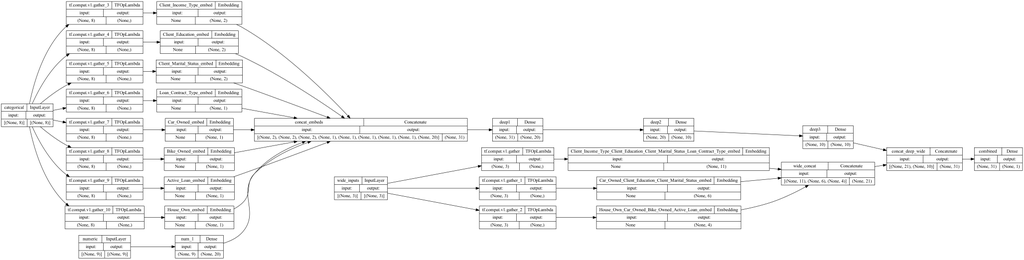

```python
from tensorflow.keras.utils import plot_model

plot_model(
    model1, show_shapes=True, show_layer_names=True,
    rankdir='LR', expand_nested=False, dpi=96
)
```

```python
from sklearn.metrics import confusion_matrix
y_pred = model1.predict([crossed_features_test.to_numpy(), categorical_features_test.to_numpy(), numerical_features_test.to_numpy()])
y_pred = np.where(y_pred > 0.5, 1, 0)

cm = confusion_matrix(y_test, y_pred)
tn = cm[0][0]
fn = cm[1][0]
print('False omission rate: ', fn/(tn+fn))
```

```
False omission rate:  0.06846772530418643
```

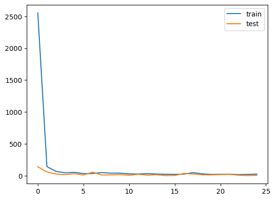

```python
import matplotlib.pyplot as plt
plt.plot(history1.history['loss'], label='train')
plt.plot(history1.history['val_loss'], label='test')
plt.legend()
```

Examining the graph, I observed the train/test loss of the network (y-axis) as the number of epochs increased (x-axis). It's evident from the graph that the network's loss started off high with considerable variance. However, with an increase in the number of epochs, the loss gradually converged, stabilizing at around 2 epochs.

### Model 2

```python
%%time
# Keras input:
from tensorflow.keras.layers import Input, Dense, concatenate, Embedding
from tensorflow.keras.models import Model
input_crossed = Input(shape=(crossed_features_train.shape[1],),
                     dtype='int64',
                     name='wide_inputs')

crossed_outputs = []
for idx,col in enumerate(cross_col_df_names):
    N = len(encoders[col].classes_)
    N_reduced = int(np.sqrt(N))
    x = tf.gather(input_crossed, idx, axis=1)
    x = Embedding(input_dim=N, output_dim=N_reduced,
     input_length=1, name=col+"_embed")(x)
    crossed_outputs.append(x)
wide_branch = concatenate(crossed_outputs, name='wide_concat')
all_deep_branch_outputs = []

input_cat = Input(shape=(X_cat.shape[1],), dtype='int64', name='categorical')
for idx,col in enumerate(categorical_headers):
    N = features[col].max()+1
    N_reduced = int(np.sqrt(N))
    x = tf.gather(input_cat, idx, axis=1)
    x = Embedding(input_dim=N,
                  output_dim=N_reduced,
                  input_length=1, name=col+'_embed')(x)
    all_deep_branch_outputs.append(x)

input_num = Input(shape=(X_num.shape[1],), name='numeric')
x_dense = Dense(units=20, activation='relu',name='num_1')(input_num)

all_deep_branch_outputs.append(x_dense)

deep_branch = concatenate(all_deep_branch_outputs,name='concat_embeds')
deep_branch = Dense(units=256,activation='relu', name='deep1')(deep_branch)
deep_branch = Dense(units=128,activation='relu', name='deep2')(deep_branch)
deep_branch = Dense(units=64,activation='relu', name='deep3')(deep_branch)
deep_branch = Dense(units=32,activation='relu', name='deep4')(deep_branch)
deep_branch = Dense(units=10,activation='relu', name='deep5')(deep_branch)

final_branch = concatenate([wide_branch, deep_branch],
                           name='concat_deep_wide')
final_branch = Dense(units=1,activation='sigmoid', name='combined')(final_branch)

model2 = Model(inputs=[input_crossed,input_cat,input_num],outputs=final_branch)

class_weight = {0: 1,
                1: 25}

model2.compile(optimizer='adam', loss='binary_crossentropy')

history2 = model2.fit([X_crossed,X_cat,X_num],
                    y_train,
                    class_weight=class_weight,
                    validation_data=([crossed_features_test.to_numpy(), categorical_features_test.to_numpy(), numerical_features_test.to_numpy()], y_test),
                    epochs=5,
                    batch_size=32,
                    verbose=1)
```

```
CPU times: user 13.7 s, sys: 4.88 s, total: 18.6 s
Wall time: 11.7 s
```

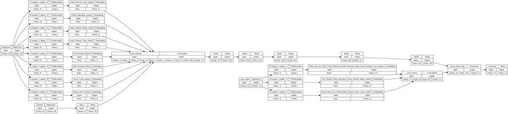

```python
from tensorflow.keras.utils import plot_model
plot_model(
    model2, show_shapes=True, show_layer_names=True,
    rankdir='LR', expand_nested=False, dpi=96
)
```

```python
from sklearn.metrics import confusion_matrix
y_pred = model2.predict([crossed_features_test.to_numpy(), categorical_features_test.to_numpy(), numerical_features_test.to_numpy()])
y_pred = np.where(y_pred > 0.5, 1, 0)

cm = confusion_matrix(y_test, y_pred)
tn = cm[0][0]
fn = cm[1][0]
print('False omission rate: ', fn/(tn+fn))
```

```
False omission rate:  0.046104928457869634
```

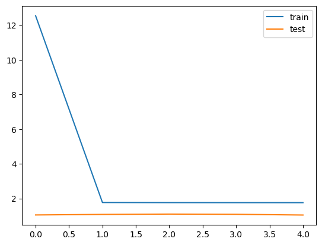

```python
plt.plot(history2.history['loss'], label='train')
plt.plot(history2.history['val_loss'], label='test')
plt.legend()
```

### Model 3

In developing my third model, I adopted the same wide and deep network structure as in the second model, particularly in terms of the fully connected layers. However, I introduced a Dropout Layer followed by a Batch Normalization layer after each Dense Layer. This addition aims to address overfitting in the deep network, where Dropout helps prevent overemphasis on specific nodes, and Batch Normalization theoretically enhances stability and aids convergence by regulating contributions from each layer.

```python
%%time
# Keras input:
from tensorflow.keras.layers import Input, Dense, concatenate, Embedding, Dropout, BatchNormalization
from tensorflow.keras.models import Model
input_crossed = Input(shape=(crossed_features_train.shape[1],),
                     dtype='int64',
                     name='wide_inputs')

crossed_outputs = []
for idx,col in enumerate(cross_col_df_names):

    N = len(encoders[col].classes_)

    N_reduced = int(np.sqrt(N))

    x = tf.gather(input_crossed, idx, axis=1)

    x = Embedding(input_dim=N, output_dim=N_reduced,
     input_length=1, name=col+"_embed")(x)

    crossed_outputs.append(x)
wide_branch = concatenate(crossed_outputs, name='wide_concat')
all_deep_branch_outputs = []

input_cat = Input(shape=(X_cat.shape[1],), dtype='int64', name='categorical')
for idx,col in enumerate(categorical_headers):

    N = features[col].max()+1
    N_reduced = int(np.sqrt(N))

    x = tf.gather(input_cat, idx, axis=1)
    x = Embedding(input_dim=N,
                  output_dim=N_reduced,
                  input_length=1, name=col+'_embed')(x)

    all_deep_branch_outputs.append(x)

input_num = Input(shape=(X_num.shape[1],), name='numeric')
x_dense = Dense(units=20, activation='relu',name='num_1')(input_num)

all_deep_branch_outputs.append(x_dense)

deep_branch = concatenate(all_deep_branch_outputs,name='concat_embeds')
deep_branch = Dense(units=256,activation='relu', name='deep1')(deep_branch)
deep_branch = Dropout(0.2)(deep_branch)
deep_branch = BatchNormalization()(deep_branch)
deep_branch = Dense(units=128,activation='relu', name='deep2')(deep_branch)
deep_branch = Dropout(0.2)(deep_branch)
deep_branch = BatchNormalization()(deep_branch)
deep_branch = Dense(units=64,activation='relu', name='deep3')(deep_branch)
deep_branch = Dropout(0.2)(deep_branch)
deep_branch = BatchNormalization()(deep_branch)
deep_branch = Dense(units=32,activation='relu', name='deep4')(deep_branch)
deep_branch = Dropout(0.2)(deep_branch)
deep_branch = BatchNormalization()(deep_branch)
deep_branch = Dense(units=10,activation='relu', name='deep5')(deep_branch)
final_branch = concatenate([wide_branch, deep_branch],
                           name='concat_deep_wide')
final_branch = Dense(units=1,activation='sigmoid', name='combined')(final_branch)

model3 = Model(inputs=[input_crossed,input_cat,input_num],outputs=final_branch)

class_weight = {0: 1,
                1: 25}

model3.compile(optimizer='adam', loss='binary_crossentropy')


history3 = model3.fit([X_crossed,X_cat,X_num],
                    y_train,
                    class_weight=class_weight,
                    validation_data=([crossed_features_test.to_numpy(), categorical_features_test.to_numpy(), numerical_features_test.to_numpy()], y_test),
                    epochs=4,
                    batch_size=256,
                    verbose=1)
```

```
CPU times: user 5.09 s, sys: 2.35 s, total: 7.44 s
Wall time: 3.98 s
```

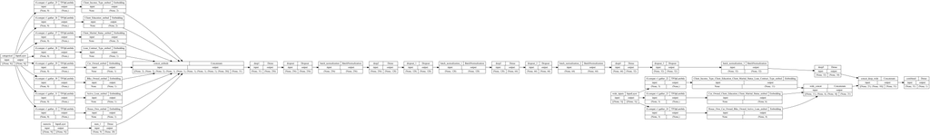

```python
from tensorflow.keras.utils import plot_model
plot_model(
    model3, to_file='model.png', show_shapes=True, show_layer_names=True,
    rankdir='LR', expand_nested=False, dpi=96
)
```

```python
from sklearn.metrics import confusion_matrix
y_pred = model3.predict([crossed_features_test.to_numpy(), categorical_features_test.to_numpy(), numerical_features_test.to_numpy()])
y_pred = np.where(y_pred > 0.5, 1, 0)

cm = confusion_matrix(y_test, y_pred)
tn = cm[0][0]
fn = cm[1][0]
print('False omission rate: ', fn/(tn+fn))
```

```
False omission rate:  0.03745318352059925
```

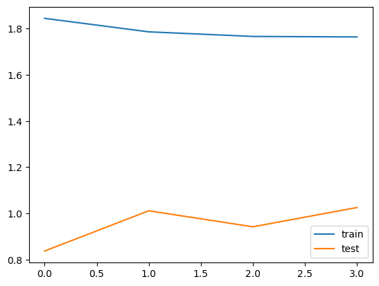

```python
plt.plot(history3.history['loss'], label='train')
plt.plot(history3.history['val_loss'], label='test')
plt.legend()
```

## MLP

```python
%%time
from tensorflow.keras.layers import Input, Dense, concatenate, Embedding
from tensorflow.keras.models import Model
all_deep_branch_outputs = []
input_cat = Input(shape=(X_cat.shape[1],), dtype='int64', name='categorical')
for idx,col in enumerate(categorical_headers):
    N = features[col].max()+1
    N_reduced = int(np.sqrt(N))

    x = tf.gather(input_cat, idx, axis=1)
    x = Embedding(input_dim=N,
                  output_dim=N_reduced,
                  input_length=1, name=col+'_embed')(x)
    all_deep_branch_outputs.append(x)
input_num = Input(shape=(X_num.shape[1],), name='numeric')
x_dense = Dense(units=20, activation='relu',name='num_1')(input_num)

all_deep_branch_outputs.append(x_dense)
deep_branch = concatenate(all_deep_branch_outputs,name='concat_embeds')
deep_branch = Dense(units=20,activation='relu', name='deep1')(deep_branch)
deep_branch = Dense(units=10,activation='relu', name='deep2')(deep_branch)
deep_branch = Dense(units=10,activation='relu', name='deep3')(deep_branch)
final_branch = Dense(units=1,activation='sigmoid', name='combined')(deep_branch)

model4 = Model(inputs=[input_cat,input_num],outputs=final_branch)

class_weight = {0: 1,
                1: 30}

model4.compile(optimizer='adam',
              loss='binary_crossentropy')
history4 = model4.fit([X_cat,X_num],
                    y_train,
                    class_weight=class_weight,
                    validation_data=([categorical_features_test.to_numpy(), numerical_features_test.to_numpy()], y_test),
                    epochs=5,
                    batch_size=512,
                    verbose=1)
```

```
CPU times: user 1.58 s, sys: 978 ms, total: 2.56 s
Wall time: 1.18 s
```

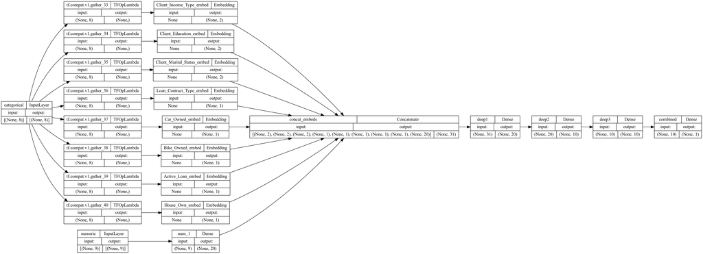

```python
from tensorflow.keras.utils import plot_model
plot_model(
    model4, show_shapes=True, show_layer_names=True,
    rankdir='LR', expand_nested=False, dpi=96
)
```

```python
from sklearn.metrics import confusion_matrix
y_pred = model4.predict([categorical_features_test.to_numpy(), numerical_features_test.to_numpy()])
y_pred = np.where(y_pred > 0.5, 1, 0)

cm = confusion_matrix(y_test, y_pred)
tn = cm[0][0]
fn = cm[1][0]
print('False omission rate: ', fn/(tn+fn))
```

```
False omission rate:  0.05785920925747348
```

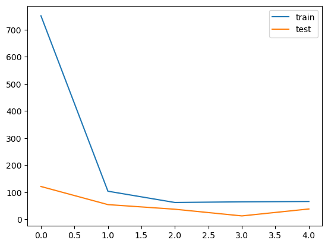

```python
plt.plot(history4.history['loss'], label='train')
plt.plot(history4.history['val_loss'], label='test')
plt.legend()
```

Upon examining the first two plots for train/test loss, I noticed a familiar pattern, with the training loss initially being quite high and converging swiftly.

To facilitate a comprehensive comparison of all these models, I propose generating ROC curves. This approach will provide a more nuanced and reliable indication of general classification performance across the different models.

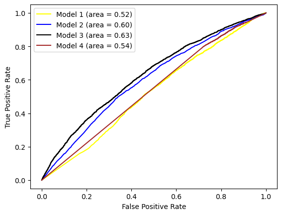

```python
from sklearn.metrics import roc_curve, auc
plt.figure()
y_pred = model1.predict([crossed_features_test.to_numpy(), categorical_features_test.to_numpy(), numerical_features_test.to_numpy()])
fpr, tpr, thresholds = roc_curve(y_test, y_pred)
roc_auc = auc(fpr, tpr)
plt.plot(fpr, tpr, color='yellow', label='Model 1 (area = %0.2f)' % roc_auc)
y_pred = model2.predict([crossed_features_test.to_numpy(), categorical_features_test.to_numpy(), numerical_features_test.to_numpy()])
fpr, tpr, thresholds = roc_curve(y_test, y_pred)
roc_auc = auc(fpr, tpr)
plt.plot(fpr, tpr, color='blue', label='Model 2 (area = %0.2f)' % roc_auc)
y_pred = model3.predict([crossed_features_test.to_numpy(), categorical_features_test.to_numpy(), numerical_features_test.to_numpy()])
fpr, tpr, thresholds = roc_curve(y_test, y_pred)
roc_auc = auc(fpr, tpr)
plt.plot(fpr, tpr, color='black', label='Model 3 (area = %0.2f)' % roc_auc)
y_pred = model4.predict([categorical_features_test.to_numpy(), numerical_features_test.to_numpy()])
fpr, tpr, thresholds = roc_curve(y_test, y_pred)
roc_auc = auc(fpr, tpr)
plt.plot(fpr, tpr, color='Brown', label='Model 4 (area = %0.2f)' % roc_auc)
plt.ylabel('True Positive Rate')
plt.xlabel('False Positive Rate')
plt.legend()
```

```python
y_pred_model3 = model3.predict([crossed_features_test.to_numpy(), categorical_features_test.to_numpy(), numerical_features_test.to_numpy()])
y_pred_model4 = model4.predict([categorical_features_test.to_numpy(), numerical_features_test.to_numpy()])
y_pred_model3 = np.where(y_pred_model3 > 0.5, 1, 0).flatten()
y_pred_model4 = np.where(y_pred_model4 > 0.5, 1, 0).flatten()

both_correct = sum((y_pred_model3 == y_pred_model4) & (y_pred_model3 == y_test))
both_wrong = sum((y_pred_model3 != y_test) & (y_pred_model4 != y_test))
model3_correct = sum((y_pred_model3 == y_test) & (y_pred_model4 != y_test))
model4_correct = sum((y_pred_model4 == y_test) & (y_pred_model3 != y_test))

both_correct, both_wrong, model3_correct, model4_correct
critical_value = (model3_correct - model4_correct - 1)**2 / (model3_correct + model4_correct)
from scipy.stats import chi2
import math
p = 1 - chi2.cdf(math.sqrt(critical_value), df=1)
```

```python
p
```

```
9.216882812523863e-11
```

## Exceptional Work: Visualizing Learned Embeddings

```python
Income_type = model3.weights[0].numpy()
Education = model3.weights[1].numpy()
Marital_Status = model3.weights[2].numpy()
Loan_type = model3.weights[3].numpy()
Car_own = model3.weights[4].numpy()
Bike_own = model3.weights[5].numpy()
Active_Loan = model3.weights[6].numpy()
House_Own = model3.weights[7].numpy()
```

```python
# print out the dimentions of the weights
print(Income_type.shape)
print(Education.shape)
print(Marital_Status.shape)
print(Loan_type.shape)
print(Car_own.shape)
print(Bike_own.shape)
print(Active_Loan.shape)
print(House_Own.shape)
```

```
(8, 2)
(5, 2)
(4, 2)
(2, 1)
(2, 1)
(2, 1)
(2, 1)
(2, 1)
```

I made the decision to focus our visualization efforts solely on income type, education, and marital status. This choice was influenced by the fact that the other variables were binary, and visualizing their embeddings would essentially reveal differences between two binary outputs. Unfortunately, such a conclusion wouldn't provide particularly useful insights.

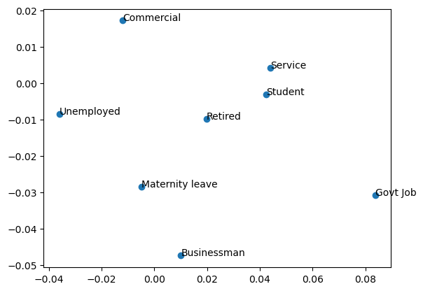

```python
plt.scatter(Income_type[:,0], Income_type[:,1])
for i,txt in enumerate(encoders["Client_Income_Type"].classes_):
    plt.annotate(txt, (Income_type[i,0], Income_type[i,1]))
```

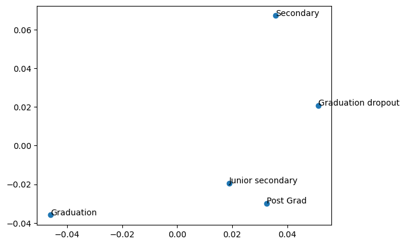

```python
plt.scatter(Education[:,0], Education[:,1])
for i,txt in enumerate(encoders["Client_Education"].classes_):
    plt.annotate(txt, (Education[i,0], Education[i,1]))
```

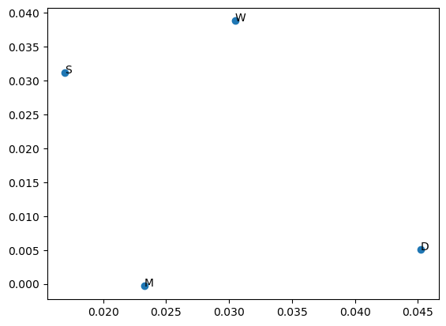

```python
plt.scatter(Marital_Status[:,0], Marital_Status[:,1])
for i,txt in enumerate(encoders["Client_Marital_Status"].classes_):
    plt.annotate(txt, (Marital_Status[i,0], Marital_Status[i,1]))
```